# Baltimore Bridges

Zachary Hamilton

November 26, 2018

```
## # A tibble: 6 x 2
##   inspection_yr     n
##           <dbl> <int>
## 1          2009     1
## 2          2013     1
## 3          2014     1
## 4          2015  1046
## 5          2016   957
## 6          2017    73
```

First thing I wanted to see was whether older bridges were generally in worse condition based on their most recent inspection. I accomplished this with a stacked bar chart that makes it easy to see the fractional distribution change over time.

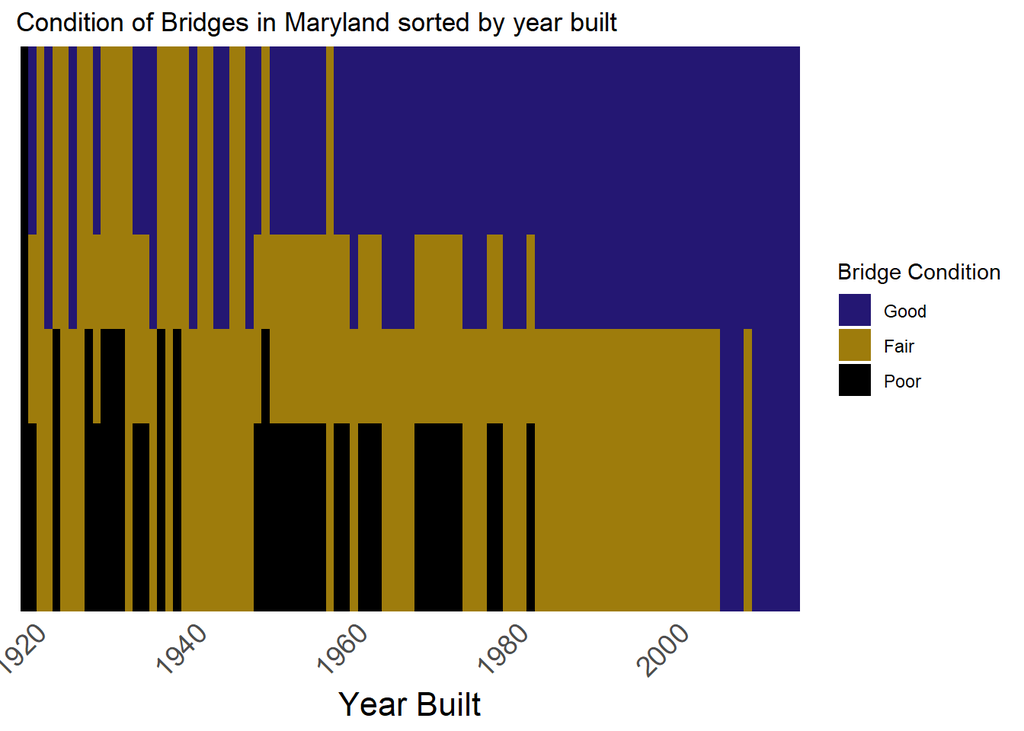

All bridges that carry a “poor” condition attribute were built before 1990. The overwhelming majority of bridges were inspected in 2015 or later. 1 each were inspected in 2009, 2013, 2014. Might be worth looking at those. Two have fairly low traffic but very high total improvement costs and one was built just recently in 2013 and maintained a good condition based on a 2014 inspection.

```
## # A tibble: 3 x 12
##     lat  long county carries yr_built bridge_condition avg_daily_traff~
##   <dbl> <dbl> <chr>  <chr>      <dbl> <fct>                       <dbl>
## 1  39.7 -76.7 Balti~ GORES ~     1920 Poor                          200
## 2  39.4 -76.4 Balti~ MOHRS ~     1912 Poor                         1600
## 3  39.2 -76.8 Howar~ OLD MO~     2013 Good                         5590
## # ... with 5 more variables: total_improve_cost_thousands <dbl>,
## #   inspection_mo <chr>, inspection_yr <dbl>, owner <chr>,
## #   responsibility <chr>
```

There are 11 bridges in operation that were built before 1900, none of which are in poor condition, all recently inspected. Let’s have a look at the bridges that are in poor condition and see if financial circumstances might be holding back repairs.

```
## # A tibble: 3 x 2
##   bridge_condition `median(total_improve_cost_thousands, na.rm = TRUE)`
##   <fct>                                                           <dbl>
## 1 Good                                                             44.5
## 2 Fair                                                            129
## 3 Poor                                                            342
```

Bridges that are in a “poor” condition would cost significantly more to repair than those in fair/good condition, as suspected.

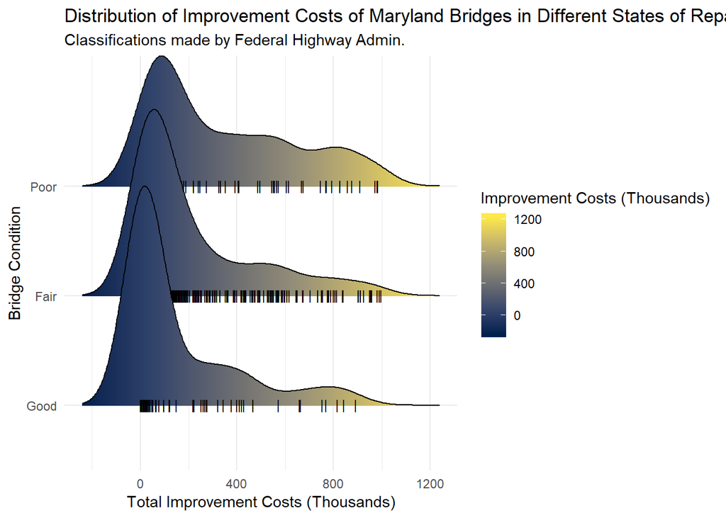

Any correlation between the condition of a bridge and the amount of traffic it receives? Maybe a heavy traffic bridge will be repaired more often and kept in good condition?

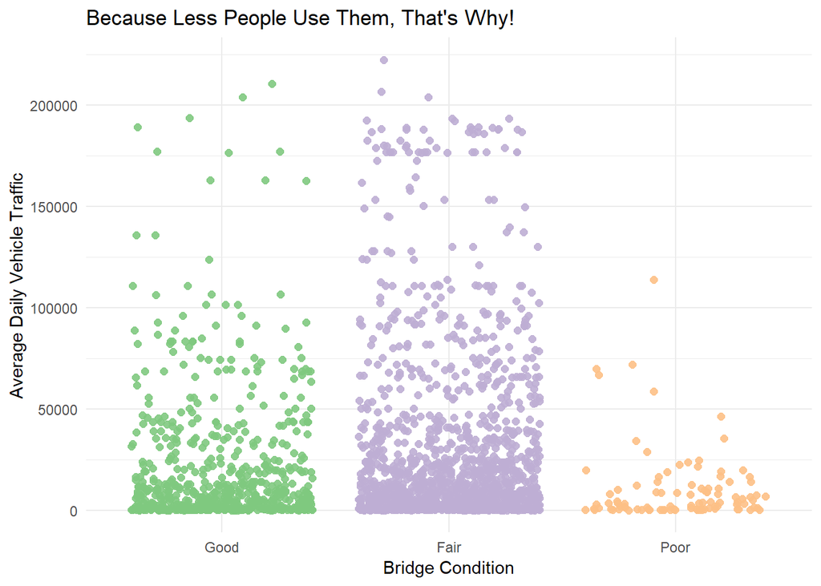

Looks like most of the bridges that are in “poor” condition have a relatively low average daily vehicle traffic. This could partly explain why they have been left in this state while priority has been given to maintaining high traffic bridges.